# Comparing the Presidential Election with the 2024 Paid Sick Leave Referendum

John Verghese

2026-01-08

Paid Sick Leave for Nebraskans and a table of progressive-allied groups, including the AFL-CIO, Planned Parenthood, and the ACLU, supported a referendum mandating paid sick leave for all working Nebraskans. Initiative 436 went on the ballot in the 2024 general election, sharing the ballot with the high-salience presidential election, downballot races, and a number of other ballot measures, including Initiative 439 to codify a woman’s right to choose. Initiative 436 proved to be the most popular item on the ballot. Nearly 75% of Nebraskans supported the measure[^1], with all but four counties (which are among the least populous in the state) returning a majority for the measure:

|  | Init 436 Support | Population |
| --- | --- | --- |
| Keya Paha | 43.9% | 939 |
| Arthur | 47.6% | 540 |
| McPherson | 48.6% | 463 |
| Hayes | 49.3% | 854 |
| All Other Counties | 74.6% | 1,963,130 |

This overwhelming support demonstrates the popularity of progressive economic measures to support working Nebraskans. In every county in the state, Initiative 436 significantly overperformed the top of the Democratic ticket:

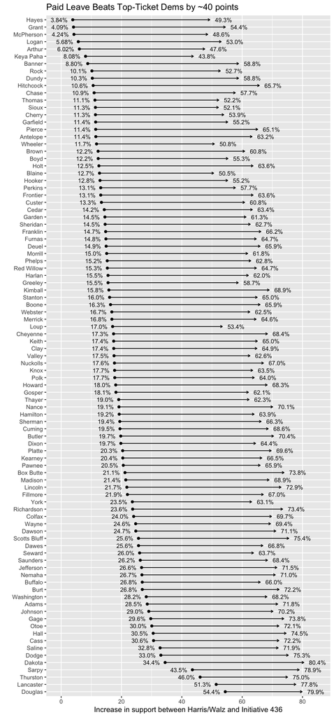

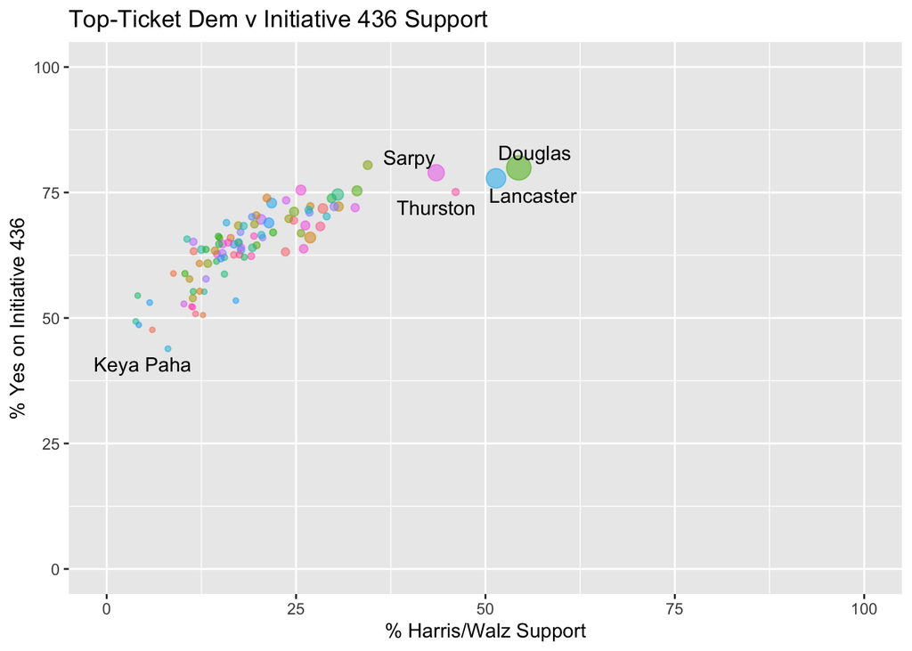

There was a strong racial and age correlation with support for the ballot measure, with young, black, and Hispanic counties returning significant support:

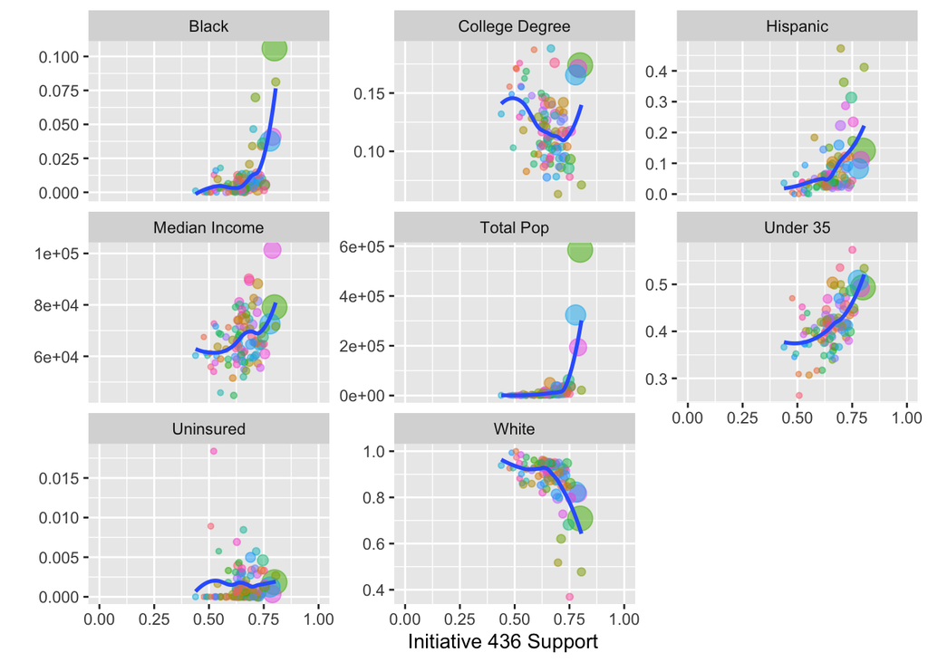

In the five counties with more than a quarter of the population identifying as Latino - Colfax, Dakota, Dawson, Hall, and Saline - paid sick leave beat the top of the ticket by ~45 points:

|  | % Latino | Population | Harris Support | Init 436 Support | Difference |
| --- | --- | --- | --- | --- | --- |
| Colfax | 47.3% | 10,541 | 24.0% | 69.8% | 45.7% |
| Dakota | 41.2% | 21,331 | 34.5% | 80.5% | 46.0% |
| Dawson | 36.3% | 24,020 | 24.7% | 71.2% | 46.4% |
| Hall | 31.3% | 62,431 | 30.5% | 74.6% | 44.1% |
| Saline | 28.7% | 14,642 | 32.8% | 72.0% | 39.2% |

The takeaway: voters in Nebraska across geographies have indicated a willingness to support progressive economic policies. Progressives in Nebraska would do well to strongly associate themselves with the success of Initiative 436, and continue to focus on economically progressive policies.

|  | Total Voters | Initiative 436 Supporters | Top-ticket Dem Supporters | Swingable Voters |
| --- | --- | --- | --- | --- |
| Latino > 25% | 46,586 | 32,169 | 13,866 | 18,303 |
| Metro | 531,771 | 398,402 | 273,570 | 124,832 |
| Rest of State | 366,679 | 230,375 | 81,581 | 148,794 |
| Thurston | 2,123 | 1,402 | 978 | 424 |

See the geographic distribution of increased support for paid sick leave vs the Harris/Walz ticket below:

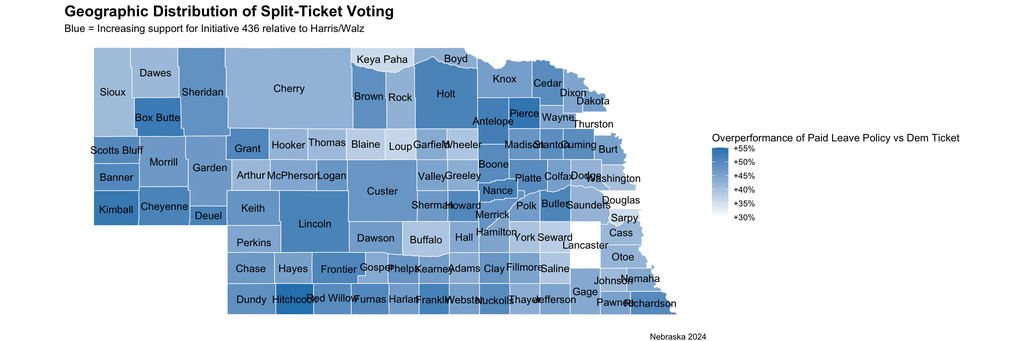

Additional analysis is available upon request, including comparison of Initiative 439, on a woman’s right to choose, with the paid sick leave and presidential elections.

*AI Disclaimer: I wrote all of the code used to generate this document, with the exception of choosing which census variables to pull into the analysis.*

[^1]: Thanks to the NE Secretary of State and the US Census Bureau for all data used to generate this report